# Heart Attack Factor Analysis

Nandika Grover

2026-03-20

# 1 Preamble: defining variables

This section demonstrates dynamic referencing in code for the dataset. We can change any names in the preamble section, in order to change the full document. This allows you to easily create new reports by just altering a few lines.

```r
setwd("/Users/nandika/Desktop/UIUC/spring 26/STAT385")
DataSet <- read.csv("heart_attack_Midterm.csv")
DataName <- "Heart Attacks in China"

x0 <- as.numeric(DataSet$Blood_Pressure)
x0name <- "Blood Pressure"
x1 <- as.factor(DataSet$Heart_Attack)
x1name <- "Heart Attack"
x2 <- as.factor(DataSet$Obesity)
x2name <- "Obesity"
x3 <- as.factor(DataSet$Rural_or_Urban)
x3name <- " Urban"
x4 <- as.factor(DataSet$Alcohol_Consumption)
x4name <- "Alcohol Consumption"
x5 <- as.factor(DataSet$Smoking_Status)
x5name <- "Smoking"
x6 <- as.factor(DataSet$Physical_Activity)
x6name <- "Physical Activity"
x7 <- as.numeric(DataSet$Age)
x7name <- "Age"
x8 <- as.factor(DataSet$Gender)
x8name <- "Gender"
```

# 2 Statistical Programming

This section demonstrates the various statistical analysis performed on the data given in the dataset Heart Attacks in China

## 2.1 Analysis of Variance

This part caters to the analysis of variance to identify the main effects between x0 (Blood Pressure) and x1 (Heart Attack), and its interaction effect with x2 (Obesity).

```r
Q1 <- aov( x0 ~ x1 * x2)
summ<- summary(Q1)
summ
```

```
##               Df  Sum Sq Mean Sq  F value  Pr(>F)
## x1             1 1261297 1261297 3434.535 < 2e-16 ***
## x2             1    3809    3809   10.373 0.00128 **
## x1:x2          1    1320    1320    3.594 0.05801 .
## Residuals   9996 3670926     367
## ---
## Signif. codes:  0 '***' 0.001 '**' 0.01 '*' 0.05 '.' 0.1 ' ' 1
```

### 2.1.1 Analysis

An ANOVA test was performed to show the relation between Heart Attack and Blood Pressure, with the latter being the dependent variable. There is also an interaction term, Obesity, which examines whether Obesity moderates the relationship between Heart Attack and Blood Pressure.

The summary of the test shows the following results:

**Heart Attack(x1):** F-value- 3434.535 and pvalue- 2e-16

**Obesity (x2):** F-value- 10.373 and pvalue- 0.00128

**Heart Attack (x1) : Obesity (x2) :** F-value- 3.594 and pvalue- 0.05801 .

The ANOVA results show that Heart Attack has a statistically significant effect on Blood Pressure (F = 3434.535, p < 0.001), while Obesity also shows a smaller but significant effect (F = 10.373, p = 0.00128). The interaction term is not statistically significant (p = 0.058), suggesting limited evidence of interaction.

### 2.1.2 Visualisations

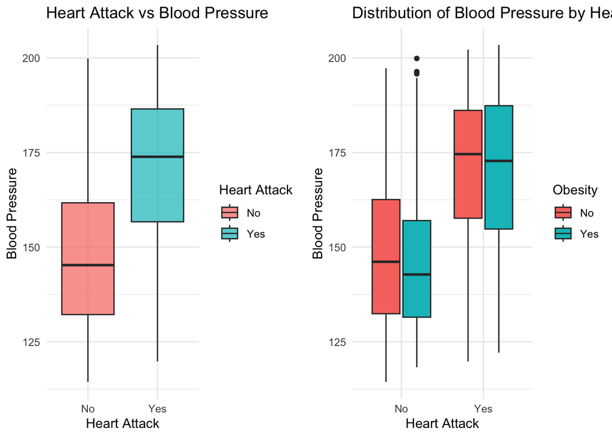

Figure 2.1: Distribution of Blood Pressure by Heart Attack

```r
library(ggplot2)
library(gridExtra)

p1 <- ggplot(DataSet, aes(x = x1, y = x0, fill = x1)) +
  geom_boxplot(alpha = 0.7) +
  labs(
    title = paste(x1name, "vs", x0name),
    x = x1name,
    y = x0name,
    fill = x1name
  ) +
  theme_minimal()

p2 <- ggplot(DataSet, aes(x=x1, y=x0, fill=x2)) +
  geom_boxplot() +
  labs(x= x1name,
       y= x0name,
       fill= x2name,
       title = paste("Distribution of", x0name, "by", x1name, "and", x2name))+
  theme_minimal()

grid.arrange(p1,p2, nrow=1)
```

The plot on the left shows the distribution of Blood Pressure across the levels of Heart Attack. From the boxplot, it is apparent that the median Blood Pressure differs between Heart Attack categories, indicating a strong main effect of Heart Attack on Blood Pressure.

## 2.2 Regression Model

This section performs regression analysis and prepares predictive model of Heart Attack using predictors Obesity , Urban and Alcohol Consumption.

```r
Q2 <- glm(x1 ~ x2 + x3 + x4 , family = binomial )
summary(Q2)
```

```
##
## Call:
## glm(formula = x1 ~ x2 + x3 + x4, family = binomial)
##
## Coefficients:
##             Estimate Std. Error z value Pr(>|z|)
## (Intercept) -0.40873    0.03526  -11.59   <2e-16 ***
## x2Yes        1.43742    0.05926   24.26   <2e-16 ***
## x3Urban     -2.42005    0.06467  -37.42   <2e-16 ***
## x4Yes        3.01044    0.07110   42.34   <2e-16 ***
## ---
## Signif. codes:  0 '***' 0.001 '**' 0.01 '*' 0.05 '.' 0.1 ' ' 1
##
## (Dispersion parameter for binomial family taken to be 1)
##
##     Null deviance: 13855.5  on 9999  degrees of freedom
## Residual deviance:  9286.6  on 9996  degrees of freedom
## AIC: 9294.6
##
## Number of Fisher Scoring iterations: 5
```

```r
DataSet$pred <- predict(Q2, type="response")
```

### 2.2.1 Analysis

This performs a logistic regression to predict the probability of Heart Attack using Obesity, Urban and Alcohol Consumption as predictors. The model estimates how each factor influences the likelihood of a Heart Attack Predicted probabilities for each individual in the dataset were then stored in DataSet$pred, which can be used to assess the distribution of risk across the population.

The summary of the model shows the following results:

**Obesity (x2):** Estimate = 1.437, z-value = 24.26, p-value < 2e-16

** Urban (x3):** Estimate = -2.420, z-value = -37.42, p-value < 2e-16

**Alcohol Consumption (x4):** Estimate = 3.010, z-value = 42.34, p-value < 2e-16

This indicates that all three predictors are highly significant in predicting Heart Attack. Specifically, being classified as Obesity increases the chances of Heart Attack, while living in an Urban area reduces it. Alcohol Consumption strongly increases the likelihood of Heart Attack. Overall, these results highlight that Obesity and Alcohol Consumption are major risk factors, whereas Urban residence appears protective.

### 2.2.2 Visualisations

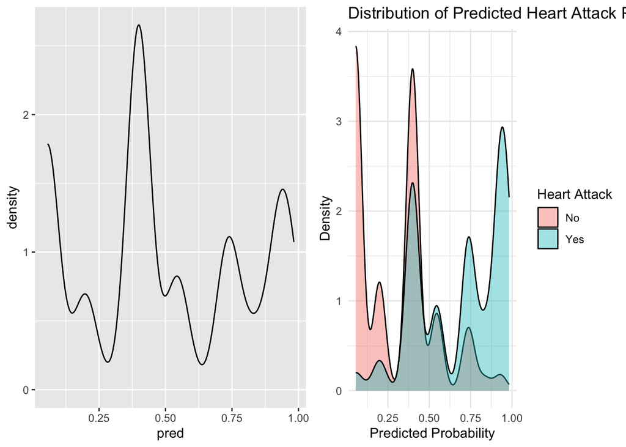

Figure 2.2: Distribution of predicted Heart Attack

```r
library(ggplot2)
p3 <- ggplot(DataSet, aes(x = pred)) +
  geom_density( alpha = 0.5)

p4 <- ggplot(DataSet, aes(x=pred, fill=x1)) +
  geom_density(alpha=0.4) +
  theme_minimal() +
  labs(title=paste("Distribution of Predicted" ,x1name ,"Probabilities"),
       x="Predicted Probability",
       y="Density",
       fill=x1name)

grid.arrange(p3,p4,nrow=1)
```

The plot on the left shows the distribution of the prediction of the regression model using a density curve. The density plot represents how the values of prediction are spread across the DatSset, with higher peaks indicating ranges where observations are more concentrated. The x-axis displays the values of prediction, while the y-axis represents the estimated probability density.The density is the maximum around 0.3 - 0.50.

The plot on the right shows the distribution of predicted probabilities through the regression model across the two groups of Heart Attack. The probability curve shows probabilities of individuals with or without Heart Attack. There is a substantial overlap between the two groups, indicating that the model does not clearly distinguish between them both. Hence it shows that the model is **not a good fit**.

## 2.3 Joe’s CaseStudy

The following study shows the demographic variables of Joe. Joe is a 40 year-old male who 1) drinks alcohol, 2) smokes, 3) lives in an urban area and 4) has low physical activity.

```r
joe <- data.frame(
  x3 = "Urban",
  x4 = "Yes",
  x5 = "Smoker",
  x6 = "Low",
  x7 = 40,
  x8 = "Male" )
```

The following code creates an appropriate prediction model to conduct analysis.

```r
Q3 <- glm(x1 ~ x3 + x4 + x5 + x6, family = binomial )
joe$pred <- predict(Q3, newdata = joe, type = "response")
```

Following are the different scenarios used to predict the risk of Heart Attackand to store them in various rows of the data frame “joe”.

```r
no_alcohol <- joe
no_alcohol$x4 <- "No"
no_alcohol$pred <- predict(Q3, newdata = no_alcohol, type = "response")

no_smoke <- joe
no_smoke$x5 <- "Non-Smoker"
no_smoke$pred <- predict(Q3, newdata = no_smoke, type = "response")

rural <- joe
rural$x3 <- "Rural"
rural$pred <- predict(Q3, newdata = rural, type = "response")

active <- joe
active$x6 <- "High"
active$pred <- predict(Q3, newdata = active, type = "response")

newrisk<- data.frame(
  newdata = c( "No Alcohol", "No Smoking", "Rural", "Increase Activity"),
  risk = c( no_alcohol$pred, no_smoke$pred, rural$pred, active$pred)
)
```

### 2.3.1 Visualisation

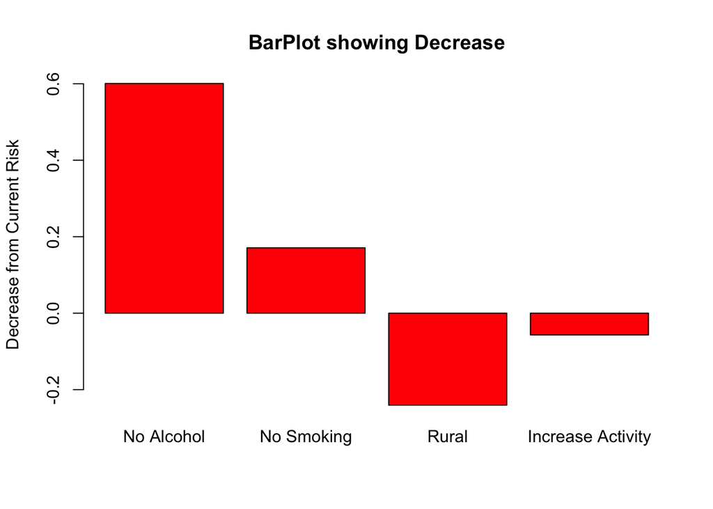

Figure 2.3: Bar chart showing the level of decrease

```r
decrease <- joe$pred - newrisk$risk
barplot( decrease , col= "red", main="BarPlot showing Decrease",
         ylab = "Decrease from Current Risk" , names.arg = newrisk$newdata)
```

The plot depicts that the decrease in the risk of a Heart Attack is maximum, when there is no Alcohol Consumption. Overall it shows that there is slight decrease with leaving Smoking. On the other hand, switching from Urban and increase Physical Activity to High from Low has a negative impact, thus increasing the chances of Heart Attack instead of lowering them.

CONCLUSION: Joe should change Alcohol Consumption in order to decrease the risk of Heart Attack.

## 2.4 Conclusion

This project caters to the various methods of analysis statistical data. The various questions, highlight different aspects. While Section 2.1 performs ANOVA on Blood Pressure and Heart Attack, Section 2.2 looks into performing regression analysis and building appropriate prediction models for the given dataset. On the other hand Section 2.3 caters to the case study of Joe and using appropriate models predicts the changes necessary to reduce the risk of Heart Attack.